# Data Update

Cindy Fajardo

2024-04-30

## Introduction

Welcome to my data update! Here I will cover how I am attempting to organize all of my data and code so that it is user friendly. I will also go over my actual code, beginning with the first code Nyssa helped me with that catapulted my research in seasonal thermal difference and their effect on owl limpets.

## Let’s Start At The Beginning

In the beginning stages of my graduate career I wanted to learn more about:

1. Owl limpet ecology
2. Seasonal temperature variability

There isn’t much literature about owl limpet ecology. But the more I learned about them, it became obvious that these organism are an important player in rocky intertidal communities. At the same time, I became aware that ENSO is not following its natural oscillating cycle, which can cause variable weather patterns.

When I pitched this idea to Nyssa, I was given the task to see if there really is a significant seasonal thermal variation in Santa Cruz Island and Cabrillo National Monument (I was proposing to work in both sites). With Nyssa’s help, I was able to create code to extract temperature data from NOAA.

## NOAA Temperature Data Extraction Journey

```r
####This tells R to use NOAA designated website and what data set to use#####
rerddap::info(datasetid = "ncdcOisst21Agg_LonPM180", url = "https://coastwatch.pfeg.noaa.gov/erddap/")
```

```
## <ERDDAP info> ncdcOisst21Agg_LonPM180
##  Base URL: https://coastwatch.pfeg.noaa.gov/erddap
##  Dataset Type: griddap
##  Dimensions (range):
##      time: (1981-09-01T12:00:00Z, 2024-04-14T12:00:00Z)
##      zlev: (0.0, 0.0)
##      latitude: (-89.875, 89.875)
##      longitude: (-179.875, 179.875)
##  Variables:
##      anom:
##          Units: degree_C
##      err:
##          Units: degree_C
##      ice:
##          Units: 1
##      sst:
##          Units: degree_C
```

```r
cnm_temp_data<-griddap(datasetx = "ncdcOisst21Agg_LonPM180", ##need to change name each time
                   url = "https://coastwatch.pfeg.noaa.gov/erddap/",
                   time = c("2020-01-01", "2022-12-31"),
                   zlev = c(0,0), # this is the depth, it wants a range
                   latitude =  c(32.67,32.67), #lat you need
                   longitude = c(-117.24,-117.24), #long you need
                   fields = "sst")$data %>% #what to look for in data
  mutate(time = as.Date(stringr::str_remove(time, "T00:00:00Z"))) %>% #setting date and removing T00:00:00z
  select(longitude, latitude, time, sst) %>%
  na.omit()%>%
  mutate(month = month(time), # extract the month
         year = year(time), #extract the year
         site = "Cabrillo National Monument",
         season  = case_when( # make a season
           month %in% c(12,1,2) ~ "winter",
           month %in% c(3,4,5) ~ "spring",
           month %in% c(6,7,8) ~ "summer",
           month %in% c(9,10,11) ~ "fall"
         ),
         season = factor(season),
         season = fct_relevel(season, c("winter","spring","summer","fall")))
```

## Visualizng The Data

Now that I have the data extracted from NOAA and as a dataframe so I can manipulate the data. I started with a simple line graph

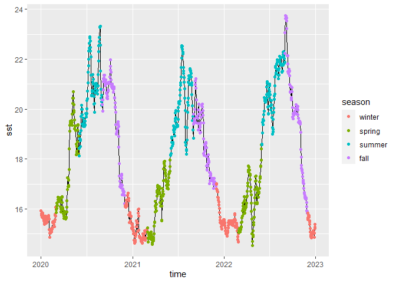

```r
#Simple line graph
ggplot(cnm_temp_data, aes(x = time, y = sst))+
  geom_line()+
  geom_point(aes(color = season))
```

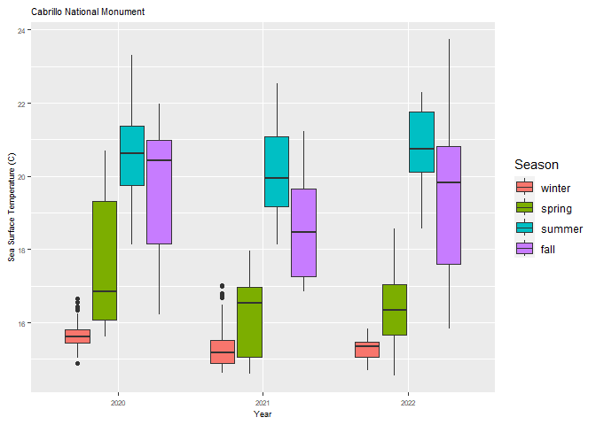

```r
#boxplot#
c <- cnm_temp_data %>%
  ggplot(aes(x = as.factor(year), y = sst, fill = season))+
  geom_boxplot()+
  labs(title = "Cabrillo National Monument",
       fill = "Season",
       x = "Year",
       y = "Sea Surface Temperature (C)")+
  theme(plot.title = element_text(size = 8),
        axis.title.y = element_text(size = 7),
        axis.title.x = element_text(size = 7),
        axis.text.x = element_text(size = 6),
        axis.text.y = element_text(size = 6))

c
```

I can also manipulate the date to make a table using the kbl function

```r
cnm_temp_data %>%
  group_by(year,season)%>% # group by year and season
  summarise(temp.mean = mean(sst, na.rm = TRUE), # average of sst
            temp.max = max(sst, na.rm = TRUE)) %>% # max sst
  kbl(caption = "Temperature data at CNM")%>% #make a table
  kable_styling(full_width = F, font_size = 9) #use this to change the font
```

Temperature data at CNM

| year | season | temp.mean | temp.max |
| --- | --- | --- | --- |
| 2020 | winter | 15.65242 | 16.65 |
| 2020 | spring | 17.53185 | 20.70 |
| 2020 | summer | 20.67630 | 23.31 |
| 2020 | fall | 19.61165 | 21.98 |
| 2021 | winter | 15.34644 | 17.01 |
| 2021 | spring | 16.23934 | 17.96 |
| 2021 | summer | 20.09163 | 22.54 |
| 2021 | fall | 18.57033 | 21.23 |
| 2022 | winter | 15.29044 | 15.83 |
| 2022 | spring | 16.35391 | 18.57 |
| 2022 | summer | 20.80087 | 22.30 |
| 2022 | fall | 19.59211 | 23.74 |

## Fast Forward to Data Collection

As I started my field data collection, I realized that I have a ton of csv files with shell length data and community surveys for sessile and mobile species. I had all of them on one repo names CSUN_Thesis. I realized my scripts were getting really long and sort of all over the place. So I decided to separate my code by topic. Now I have repo’s for growth, grazing, and community composition. Check out my [github](https://github.com/cfajardo7?tab=repositories).

It is still a work in progress. Navigate to the L_gigantea_growth repo. All of my repos will look like this. As I continue with data collection, my repo will continue to grow and change.

I decided to split up my scripts to “visualizations” and “analysis”.

The visualizations scripts will only be that, a way to visualize raw data after collection. Here is a snip it of the code I use to visualize population size per season:

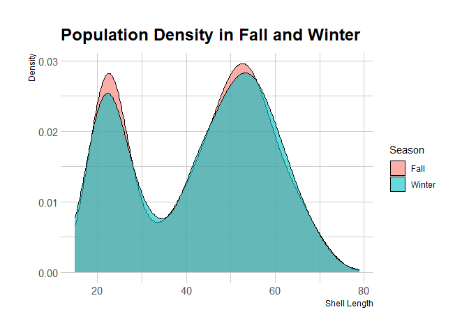

```r
m <- master_sl %>%
  ggplot( aes(x=SL_mm)) +
    geom_density(aes(fill = Season), alpha = 0.6)+
  labs(title = "Population Density in Fall and Winter",
       x = "Shell Length",
       y = "Density")+
    theme_ipsum()

m
```

I try to visualize the data before running any stats. The graph above shows population density by shell length per season. Once I visualize the data, I then run statistics on it. The chunk below is a Mann-Whitney test on the shell lenth data by season

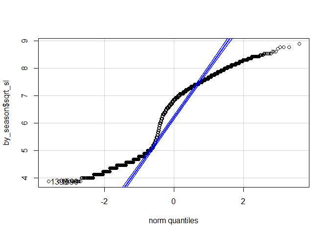

```
## [1] 1399 1590
```

```r
by_season <- master_sl %>%
  select(Season, SL_mm) %>%
  group_by(Season) %>%
  mutate(sqrt_sl = sqrt(SL_mm))

qqPlot(by_season$sqrt_sl)
```

```r
season_ttest <- t.test(log(SL_mm)~Season, data = by_season)
season_ttest
```

```
##
##  Welch Two Sample t-test
##
## data:  log(SL_mm) by Season
## t = -0.32181, df = 2980.1, p-value = 0.7476
## alternative hypothesis: true difference in means between group Fall and group Winter is not equal to 0
## 95 percent confidence interval:
##  -0.03402756  0.02443270
## sample estimates:
##   mean in group Fall mean in group Winter
##             3.673562             3.678360
```

```r
season_wilcoxtest <- wilcox.test(SL_mm~Season, data = by_season, paired=FALSE)
season_wilcoxtest
```

```
##
##  Wilcoxon rank sum test with continuity correction
##
## data:  SL_mm by Season
## W = 1296003, p-value = 0.6535
## alternative hypothesis: true location shift is not equal to 0
```

The stats show that there is no significant difference in population means. I ran this test instead of a student’s ttest since my data did not meet the assumptions of a ttest.

I hope you enjoyed my data update. Stay tuned for more!